# ELEN 6885 Reinforcement Learning coding assignment

Your code should remain in the block marked by  
############################  
# YOUR CODE STARTS HERE  
# YOUR CODE ENDS HERE  
############################  
Please don't edit anything outside the block.

```python
% load_ext autoreload
% autoreload 2
import numpy as np
import random
import matplotlib.pyplot as plt
import gym
```

## 1. Incremental Implementation of Average

We've finished the incremental implementation of average for you. Please call the function estimate with 1/step step size and fixed step size to compare the difference between this two on a simulated Bandit problem.  
(2 pts)

```python
from RLalgs.utils import estimate
random.seed(6885)
numTimeStep = 10000
q_h = np.zeros(numTimeStep + 1) # Q Value estimate with 1/step step size
q_f = np.zeros(numTimeStep + 1) # Q value estimate with fixed step size
FixedStepSize = 0.5 #A large number to exaggerate the difference
for step in range(1, numTimeStep + 1):
    if step < numTimeStep / 2:
        r = random.gauss(mu = 1, sigma = 0.1)
    else:
        r = random.gauss(mu = 3, sigma = 0.1)

    ############################
    q_h[step] = estimate(q_h[step-1],1/step,r)
    q_f[step] = estimate(q_f[step-1],FixedStepSize,r)
    ############################

q_h = q_h[1:]
q_f = q_f[1:]
```

```
RLalgs is a package containing Reinforcement Learning algorithms Epsilon-Greedy, Policy Iteration, Value Iteration, Q-Learning, and SARSA.
```

Plot the two Q value estimates. (Please include a title, labels on both axes, and legends)  
(3 pts)

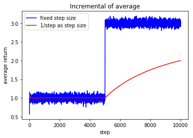

```python
############################
plt.plot(range(1,len(q_f)+1),q_f,color='blue',label='fixed step size')
plt.plot(range(1,len(q_h)+1),q_h,color='red',label='1/step as step size')
plt.title('Incremental of average')
plt.xlabel('step')
plt.ylabel('average return')
plt.legend()
plt.show()
############################
```

## 2. $\epsilon$-Greedy for Exploration

In Reinforcement Learning, we are always faced with the dilemma of exploration and exploitation. $\epsilon$-Greedy is a trade-off between them. You are gonna implement Greedy and $\epsilon$-Greedy. We combine these two policies in one function by treating Greedy as $\epsilon$-Greedy where $\epsilon = 0$. Edit the function epsilon_greedy in ./RLalgs/utils.py.  
(5 pts)

```python
from RLalgs.utils import epsilon_greedy
np.random.seed(6885) #Set the seed to cancel the randomness
q = np.random.normal(0, 1, size = 5)
############################
greedy_action = epsilon_greedy(q, 0) #Use epsilon = 0 for Greedy
e_greedy_action = epsilon_greedy(q,0.1) #Use epsilon = 0.1
############################
print('Values:')
print(q)
print('Greedy Choice =', greedy_action)
print('Epsilon-Greedy Choice =', e_greedy_action)
```

```
Values:
[ 0.61264537  0.27923079 -0.84600857  0.05469574 -1.09990968]
Greedy Choice = 0
Epsilon-Greedy Choice = 0
```

You should get the following results.  
Values:  
[ 0.61264537 0.27923079 -0.84600857 0.05469574 -1.09990968]  
Greedy Choice = 0

## 3. Frozen Lake Environment

```python
env = gym.make('FrozenLake-v0')
```

### 3.1 Derive Q value from V value

Edit function actionevaluation in ./RLalgs/utils.py.  
TIPS: $q(s, a)=\sum{s',r}p(s',r|s,a)(r+\gamma v(s'))$  
(5 pts)

```python
from RLalgs.utils import action_evaluation
v = np.ones(16)
q = action_evaluation(env = env.env, gamma = 1, v = v)
print('Action values:')
print(q)
```

```
Action values:
[[1.         1.         1.         1.        ]
 [1.         1.         1.         1.        ]
 [1.         1.         1.         1.        ]
 [1.         1.         1.         1.        ]
 [1.         1.         1.         1.        ]
 [1.         1.         1.         1.        ]
 [1.         1.         1.         1.        ]
 [1.         1.         1.         1.        ]
 [1.         1.         1.         1.        ]
 [1.         1.         1.         1.        ]
 [1.         1.         1.         1.        ]
 [1.         1.         1.         1.        ]
 [1.         1.         1.         1.        ]
 [1.         1.         1.         1.        ]
 [1.         1.33333333 1.33333333 1.33333333]
 [1.         1.         1.         1.        ]]
```

You should get Q values all equal to one except at State 14

Pseudo-codes of the following four algorithms can be found on Page 80, 83, 130, 131 of the Sutton's book.

### 3.2 Model-based RL algorithms

```python
from RLalgs.utils import action_evaluation, action_selection, render
```

### 3.2.1 Policy Iteration

Edit the function policy_iteration and relevant functions in ./RLalgs/pi.py to implement the Policy Iteration Algorithm.  
(15 pts)

```python
from RLalgs.pi import policy_iteration
V, policy, numIterations = policy_iteration(env = env.env, gamma = 1, max_iteration = 500, theta = 1e-7)
print('State values:')
print(V)
print('Number of iterations to converge =', numIterations)
```

```
State values:
[0.82352709 0.82352631 0.82352576 0.82352547 0.82352726 0.
 0.5294101  0.         0.82352758 0.82352804 0.76470468 0.
 0.         0.88235197 0.94117597 0.        ]
Number of iterations to converge = 500
```

You should get values close to:  
State values:  
[0.82352774 0.8235272 0.82352682 0.82352662 0.82352791 0.  
0.52941063 0. 0.82352817 0.82352851 0.76470509 0.  
0. 0.88235232 0.94117615 0.]

```python
#Uncomment and run the following to evaluate your result, comment them when you generate the pdf
# Q = action_evaluation(env = env.env, gamma = 1, v = V)
# policy_estimate = action_selection(Q)
# render(env, policy_estimate)
```

### 3.2.2 Value Iteration

Edit the function value_iteration and relevant functions in ./RLalgs/vi.py to implement the Value Iteration Algorithm.  
(10 pts)

```python
from RLalgs.vi import value_iteration
V, policy, numIterations = value_iteration(env = env.env, gamma = 1, max_iteration = 500, theta = 1e-7)
print('State values:')
print(V)
print('Number of iterations to converge =', numIterations)
```

```
State values:
[0.82352523 0.82352383 0.82352283 0.82352232 0.82352553 0.
 0.52940877 0.         0.82352612 0.82352695 0.76470371 0.
 0.         0.88235119 0.94117556 0.        ]
Number of iterations to converge = 501
```

You should get values close to:  
State values:  
[0.82352773 0.82352718 0.8235268 0.8235266 0.8235279 0.  
0.52941062 0. 0.82352816 0.8235285 0.76470509 0.  
0. 0.88235231 0.94117615 0.]

```python
#Uncomment and run the following to evaluate your result, comment them when you generate the pdf
Q = action_evaluation(env = env.env, gamma = 1, v = V)
policy_estimate = action_selection(Q)
render(env, policy_estimate)
```

```
  (Left)
SFFF
FHFH
FFFH
HFFG
  (Left)
SFFF
FHFH
FFFH
HFFG
  (Left)
SFFF
FHFH
FFFH
HFFG
  (Left)
SFFF
FHFH
FFFH
HFFG
  (Left)
SFFF
FHFH
FFFH
HFFG
  (Left)
SFFF
FHFH
FFFH
HFFG
  (Left)
SFFF
FHFH
FFFH
HFFG
  (Left)
SFFF
FHFH
FFFH
HFFG
```

[output cut: 41 more lines]

```
SFFF
FHFH
FFFH
HFFG
  (Down)
SFFF
FHFH
FFFH
HFFG
  (Down)
SFFF
FHFH
FFFH
HFFG
Episode ends. Reward = 1.0
```

### 3.3 Model free RL algorithms

### 3.3.1 Q-Learning

Edit the function QLearning in ./RLalgs/ql.py to implement the Q-Learning Algorithm.  
(10 pts)

```python
from RLalgs.ql import QLearning
Q = QLearning(env = env.env, num_episodes = 1000, gamma = 1, lr = 0.1, e = 0.1)
print('Action values:')
print(Q)
```

```
Action values:
[[0.53626902 0.28700065 0.37083136 0.35562069]
 [0.07941781 0.02206704 0.11250241 0.41991334]
 [0.30415307 0.14158187 0.10290878 0.11687585]
 [0.16750769 0.0292683  0.01777062 0.02874035]
 [0.53793226 0.28936166 0.31562235 0.33957109]
 [0.         0.         0.         0.        ]
 [0.22357607 0.1105446  0.10287746 0.06472732]
 [0.         0.         0.         0.        ]
 [0.24584524 0.22294452 0.23305056 0.53870761]
 [0.19365998 0.5382263  0.28575373 0.19410998]
 [0.50692255 0.21937493 0.26694037 0.1470182 ]
 [0.         0.         0.         0.        ]
 [0.         0.         0.         0.        ]
 [0.20416558 0.34344972 0.57076554 0.2173443 ]
 [0.3056124  0.66221397 0.5308133  0.64461924]
 [0.         0.         0.         0.        ]]
```

Generally, you should get non-zero action values on non-terminal states.

```python
#Uncomment the following to evaluate your result, comment them when you generate the pdf
env = gym.make('FrozenLake-v0')
policy_estimate = action_selection(Q)
render(env, policy_estimate)
```

```
  (Left)
SFFF
FHFH
FFFH
HFFG
  (Left)
SFFF
FHFH
FFFH
HFFG
  (Left)
SFFF
FHFH
FFFH
HFFG
  (Left)
SFFF
FHFH
FFFH
HFFG
  (Left)
SFFF
FHFH
FFFH
HFFG
  (Left)
SFFF
FHFH
FFFH
HFFG
  (Left)
SFFF
FHFH
FFFH
HFFG
  (Left)
SFFF
FHFH
FFFH
HFFG
```

[output cut: 71 more lines]

```
SFFF
FHFH
FFFH
HFFG
  (Down)
SFFF
FHFH
FFFH
HFFG
  (Down)
SFFF
FHFH
FFFH
HFFG
Episode ends. Reward = 1.0
```

### 3.3.2 SARSA

Edit the function SARSA in ./RLalgs/sarsa.py to implement the SARSA Algorithm.  
(10 pts)

```python
from RLalgs.sarsa import SARSA
Q = SARSA(env = env.env, num_episodes = 1000, gamma = 1, lr = 0.1, e = 0.1)
print('Action values:')
print(Q)
```

```
Action values:
[[0.16833984 0.09061764 0.10791985 0.11742527]
 [0.09381319 0.01401956 0.01301905 0.03852507]
 [0.06387078 0.01744595 0.01896129 0.00396717]
 [0.02813797 0.00104683 0.00193385 0.00728037]
 [0.18958265 0.09243483 0.11717068 0.07550387]
 [0.         0.         0.         0.        ]
 [0.17387412 0.03554461 0.01262472 0.00434869]
 [0.         0.         0.         0.        ]
 [0.12288865 0.11180219 0.12211325 0.21578299]
 [0.08503356 0.31324303 0.16981733 0.09761022]
 [0.32614535 0.20309087 0.16875918 0.07368346]
 [0.         0.         0.         0.        ]
 [0.         0.         0.         0.        ]
 [0.11234688 0.13372123 0.36920825 0.25817196]
 [0.25238401 0.6499322  0.29172365 0.38669874]
 [0.         0.         0.         0.        ]]
```

Generally, you should get non-zero action values on non-terminal states.

```python
#Uncomment the following to evaluate your result, comment them when you generate the pdf
env = gym.make('FrozenLake-v0')
policy_estimate = action_selection(Q)
render(env, policy_estimate)
```

```
  (Left)
SFFF
FHFH
FFFH
HFFG
  (Left)
SFFF
FHFH
FFFH
HFFG
  (Left)
SFFF
FHFH
FFFH
HFFG
  (Left)
SFFF
FHFH
FFFH
HFFG
  (Left)
SFFF
FHFH
FFFH
HFFG
  (Up)
SFFF
FHFH
FFFH
HFFG
  (Down)
SFFF
FHFH
FFFH
HFFG
  (Right)
SFFF
FHFH
FFFH
HFFG
  (Right)
SFFF
FHFH
FFFH
HFFG
  (Down)
SFFF
FHFH
FFFH
HFFG
  (Right)
SFFF
FHFH
FFFH
HFFG
  (Down)
SFFF
FHFH
FFFH
HFFG
Episode ends. Reward = 1.0
```

### 3.4 Human

You can play this game if you are interested. See if you can get the frisbee either with or without the model.

```python
from RLalgs.utils import human_play
#Uncomment and run the following to play the game, comment it when you generate the pdf
env = gym.make('FrozenLake-v0')
human_play(env)
```

```
Action indices: LEFT = 0, DOWN = 1, RIGHT = 2, UP = 3

SFFF
FHFH
FFFH
HFFG
Give the environment your action index:0
  (Left)
SFFF
FHFH
FFFH
HFFG
Give the environment your action index:0
  (Left)
SFFF
FHFH
FFFH
HFFG
Give the environment your action index:0
  (Left)
SFFF
FHFH
FFFH
HFFG
Give the environment your action index:0
  (Left)
SFFF
FHFH
FFFH
HFFG
Give the environment your action index:0
  (Left)
SFFF
FHFH
FFFH
HFFG
Give the environment your action index:3
  (Up)
SFFF
FHFH
```

[output cut: 203 more lines]

```
FHFH
FFFH
HFFG
Give the environment your action index:2
  (Right)
SFFF
FHFH
FFFH
HFFG
Give the environment your action index:2
  (Right)
SFFF
FHFH
FFFH
HFFG
```

## 4. Exploration VS. Exploitation

Try to reproduce Figure 2.2 (the upper one is enough) of the Sutton's book based on the experiment described in Chapter 2.3.  
Extra credit (3 pts)

```python
# Do the experiment and record average reward acquired in each time step
############################
# YOUR CODE STARTS HERE
from RLalgs.utils import estimate
from RLalgs.utils import epsilon_greedy
means=[0.3,-1,1.5,0.5,1.2,-1.5,-0.3,-1,0.7,0.5]
maxSteps=100
q_e0=np.zeros(maxSteps+1) # greedy
q_e1=np.zeros(maxSteps+1) # greedy with 0.01 epsilon
q_e2=np.zeros(maxSteps+1) #greedy with 0.1 epsilon

a_e0=np.zeros_like(means) # counts of actions in greedy policy
a_e1=np.zeros_like(means)  # counts of actions in 0.01 epsilon greedy policy
a_e2=np.zeros_like(means) # counts of actions in 0.1 epsilon greedy policy

v_e0=np.zeros_like(means) # values of actions in greedy policy
v_e1=np.zeros_like(means)  # values of actions in 0.01 epsilon greedy policy
v_e2=np.zeros_like(means) # values of actions in 0.1 epsilon greedy policy

for i in range(1,maxSteps+1):
    a=epsilon_greedy(v_e0,0)
    r=np.random.normal(means[a], scale=0.1, size=1)
    a_e0[a]+=1
    v_e0[a]=estimate(v_e0[a],1/a_e0[a],r)
    q_e0[i]=estimate(q_e0[i-1],1/i,r)

for i in range(1,maxSteps+1):
    a=epsilon_greedy(v_e1,0.01)
    r=np.random.normal(means[a],scale=0.1, size=1)
    a_e1[a]+=1
    v_e1[a]=estimate(v_e1[a],1/a_e1[a],r)
    q_e1[i]=estimate(q_e1[i-1],1/i,r)

for i in range(1,maxSteps+1):
    a=epsilon_greedy(v_e2,0.1)
    r=np.random.normal(means[a],scale=0.1, size=1)
    a_e2[a]+=1
    v_e2[a]=estimate(v_e2[a],1/a_e2[a],r)
    q_e2[i]=estimate(q_e2[i-1],1/i,r)

q_e0=q_e0[1:] # greedy
q_e1=q_e1[1:] # greedy with 0.01 epsilon
q_e2=q_e2[1:]

# YOUR CODE ENDS HERE
############################
```

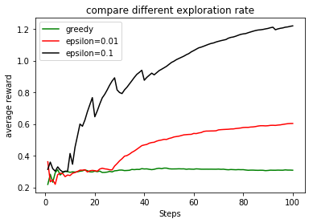

```python
# Plot the average reward
############################
plt.plot(range(1,len(q_e0)+1),q_e0,color='green',label='greedy')
plt.plot(range(1,len(q_e1)+1),q_e1,color='red',label='epsilon=0.01')
plt.plot(range(1,len(q_e2)+1),q_e2,color='black',label='epsilon=0.1')

plt.title('compare different exploration rate')
plt.xlabel('Steps')
plt.ylabel('average reward')
plt.legend()
plt.show()
############################
```

You should get curves similar to that in the book.